# CAP5 Clustering

2022-06-16

# 5.1 Objetivos de este capítulo

- Estudie los diferentes tipos de datos que se pueden agrupar de manera beneficiosa.
- Ver medidas de (des)similitud y distancias que nos ayudan a definir clusters.
- Descubra el agrupamiento oculto o latente dividiendo los datos en más reducidos.
- Utilice la agrupación cuando se le den biomarcadores en cada una de cientos de miles de células. Veremos que, por ejemplo, las células inmunitarias se pueden agrupar naturalmente en subpoblaciones estrechas.
- Ejecutar algoritmos no paramétricos como $k$-significa , $k$-medoides en datos reales de una sola celda.
- Experimente con enfoques recursivos de agrupamiento que combinen observaciones y grupos en una jerarquía de conjuntos; estos métodos se conocen como agrupamiento jerárquico .
- Estudie cómo validar clústeres a través de enfoques de arranque basados en remuestreo, que demostraremos en un conjunto de datos de una sola celda.

# 5.2 ¿Qué son los datos y por qué los agrupamos?

```r
#PAQUETES
library(pacman)
p_load("MASS","RColorBrewer","ggplot2")
```

**Distancia basada en correlación**

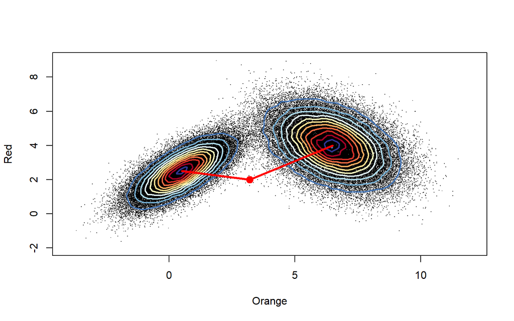

```r
set.seed(101)
n <- 60000
S1=matrix(c(1,.72,.72,1), ncol=2)
S2=matrix(c(1.5,-0.6,-0.6,1.5),ncol=2)
mu1=c(.5,2.5)
mu2=c(6.5,4)
X1 = mvrnorm(n, mu=c(.5,2.5), Sigma=matrix(c(1,.72,.72,1), ncol=2))
X2 = mvrnorm(n,mu=c(6.5,4), Sigma=matrix(c(1.5,-0.6,-0.6,1.5),ncol=2))
# A color palette from blue to yellow to red
k = 11
my.cols <- rev(brewer.pal(k, "RdYlBu"))
plot(X1, xlim=c(-4,12),ylim=c(-2,9), xlab="Orange", ylab="Red", pch='.', cex=1)
points(X2, pch='.', cex=1)
# Draw the colored contour lines
# compute 2D kernel density, see MASS book, pp. 130-131
z1 = kde2d(X1[,1], X1[,2], n=50)
z2 = kde2d(X2[,1], X2[,2], n=50)
contour(z1, drawlabels=FALSE, nlevels=k, col=my.cols, add=TRUE, lwd=2)
contour(z2, drawlabels=FALSE, nlevels=k, col=my.cols, add=TRUE, lwd=2)
points(3.2,2,pch=20,cex=2.2,col="red")
lines(c(3.2,6.5),c(2,4),col="red",lwd=3)
lines(c(3.2,.5),c(2,2.5),col="red",lwd=3)
```

## 5.3.1 Cálculos relacionados con distancias en R

```r
mx  = c(0, 0, 0, 1, 1, 1)
my  = c(1, 0, 1, 1, 0, 1)
mz  = c(1, 1, 1, 0, 1, 1)
mat = rbind(mx, my, mz)
dist(mat)
```

```
##          mx       my
## my 1.732051
## mz 2.000000 1.732051
```

```r
dist(mat, method = "binary")
```

```
##           mx        my
## my 0.6000000
## mz 0.6666667 0.5000000
```

Puede acceder al conjunto de datos aquí

```r
load("../data/Morder.RData")
sqrt(sum((Morder[1, ] - Morder[2, ])^2))
```

```
## [1] 5.593667
```

```r
as.matrix(dist(Morder))[2, 1]
```

```
## [1] 5.593667
```

Veamos cómo calcularíamos la distancia de Jaccard que definimos anteriormente entre las cepas de VIH.

```r
mut = read.csv("../data/HIVmutations.csv")
mut[1:3, 10:16]
```

```
##   p32I p33F p34Q p35G p43T p46I p46L
## 1    0    1    0    0    0    0    0
## 2    0    1    0    0    0    1    0
## 3    0    1    0    0    0    0    0
```

# 5.4 Detección de mezcla no paramétrica

## 5.4.1 K-métodos: k -significa, k -medoides y PAM

```r
p_load("vegan")
mutJ = vegdist(mut, "jaccard")
mutC = sqrt(2 * (1 - cor(t(mut))))
mutJ
```

```
##           1         2         3         4
## 2 0.8000000
## 3 0.7500000 0.8888889
## 4 0.9000000 0.7777778 0.8461538
## 5 1.0000000 0.8000000 0.8888889 0.9000000
```

```r
as.dist(mutC)
```

```
##          1        2        3        4
## 2 1.186342
## 3 1.104026 1.302931
## 4 1.318368 1.133893 1.298780
## 5 1.452966 1.186342 1.302931 1.318368
```

Ejemplo de ejecución de la k -significa algoritmo. Los centros (círculos negros) y grupos (colores) iniciales elegidos al azar se muestran en el panel superior. Los miembros del grupo se asignan en función de su distancia a los centros. En cada iteración, los centros de grupo se redefinen y los puntos se reasignan a los centros de clúster.

```r
set.seed(248811)
Xmat = matrix(runif(100), ncol = 2)
nk = 3
cents = Xmat[sample(nrow(Xmat), nk, replace = FALSE), ]
# default distance: Euclidean
dist1 = function(vec){dist(rbind(vec, cents[1,]))}
dist2 = function(vec){dist(rbind(vec, cents[2,]))}
dist3 = function(vec){dist(rbind(vec, cents[3,]))}
dists123 = cbind(apply(Xmat, 1, dist1),
                 apply(Xmat, 1, dist2),
                 apply(Xmat, 1, dist3))
clust0 = apply(dists123, 1, which.min)
out1 = kmeans(Xmat, cents, iter.max=1)
```

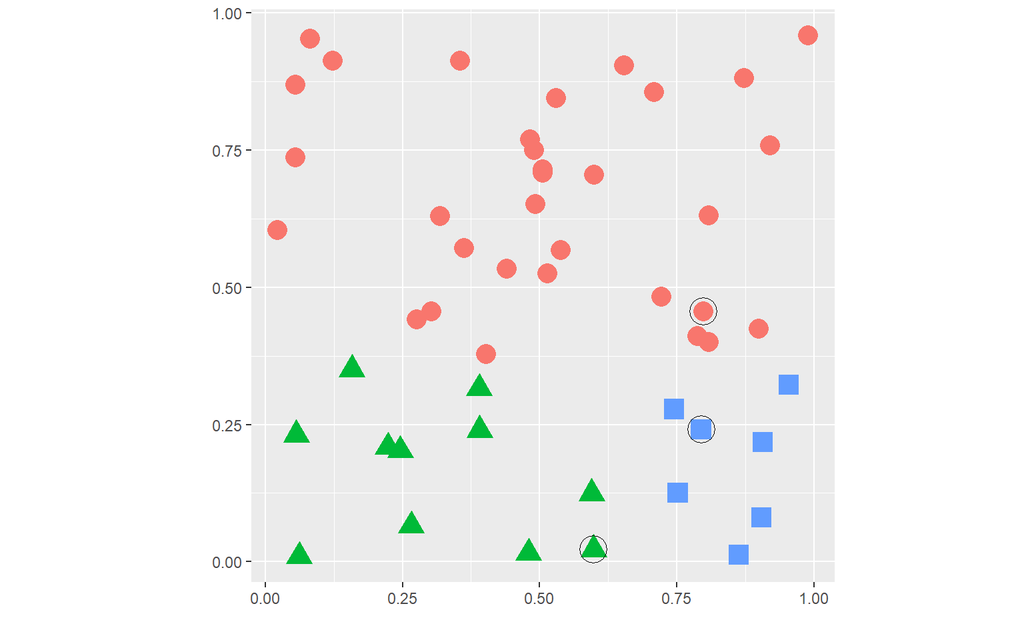

```r
out2 = kmeans(Xmat, cents, iter.max=3)
data0 = data.frame(x = Xmat[,1],
                   y = Xmat[,2],
                   cluster = as.factor(clust0))
data1 = data.frame(x = Xmat[,1],
                   y = Xmat[,2],
                   cluster = as.factor(out1$cluster))
data2 = data.frame(x = Xmat[,1],
                   y = Xmat[,2],
                   cluster = as.factor(out2$cluster))

.mp = function(v, cdg) {
  ggplot(data = v, aes(x = x, y = y)) +
  geom_point(aes(col = cluster, shape = cluster), size = 5) + xlab("") + ylab("") +
  geom_point(data = cdg, fill = "black", size = 7, shape = 1) +
  scale_shape_discrete(solid = TRUE, guide = "none") + guides(col = "none") + coord_fixed()
}
# centers of clusters:
cdg = data.frame(x = cents[,1],y = cents[,2])
.mp(data0, cdg)
```

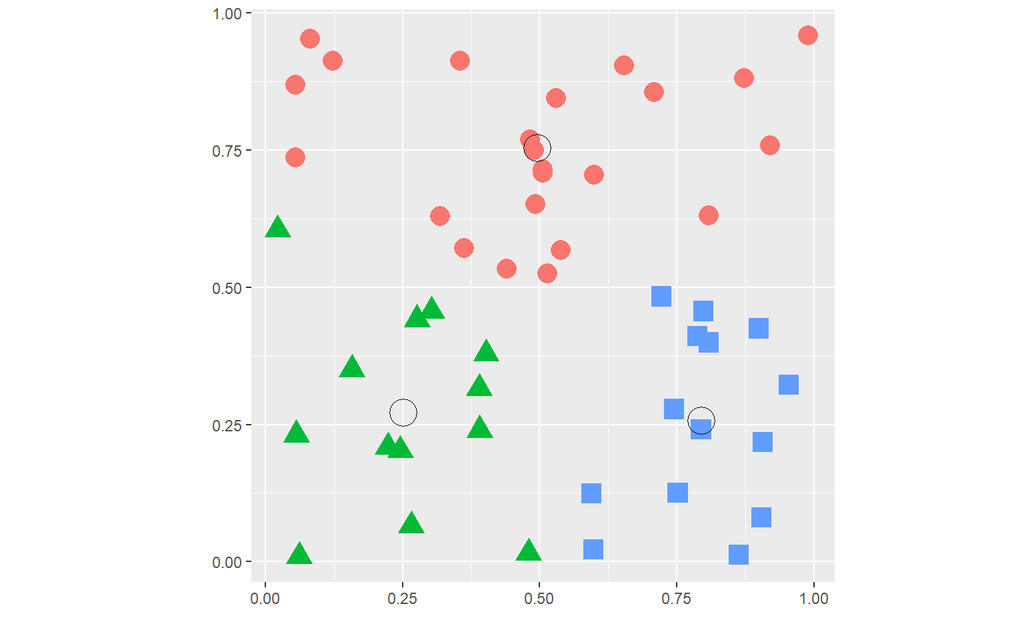

```r
cents = out1$centers
cdg1 = data.frame(x=cents[,1],y=cents[,2])
.mp(data1, cdg1)
```

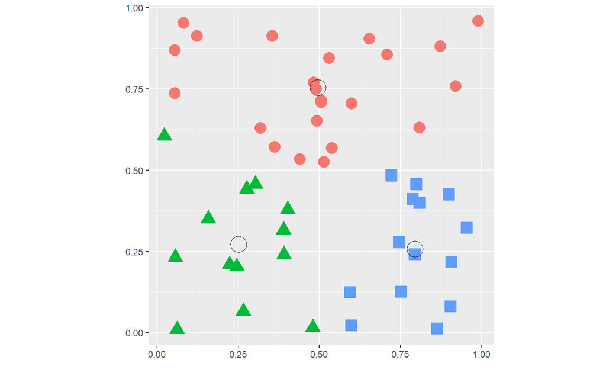

```r
cents = out2$centers
cdg2 = data.frame(x=cents[,1],y=cents[,2])
.mp(data2, cdg2)
```

```r
p_load(scRNAseq)
.oldMar = par("mar")
par(mar = c(1.1, 6, 4.1, 1.1))
p_load("clusterExperiment")
fluidigm = scRNAseq::ReprocessedFluidigmData()
se = fluidigm[, fluidigm$Coverage_Type == "High"]
assays(se) = list(normalized_counts =
   round(limma::normalizeQuantiles(assay(se))))
ce = clusterMany(se, clusterFunction = "pam", ks = 5:10, run = TRUE,
  isCount = TRUE, reduceMethod = "var", nFilterDims = c(60, 100, 150))
```

```
## 18 parameter combinations, 0 use sequential method, 0 use subsampling method
## Running Clustering on Parameter Combinations...
## done.
```

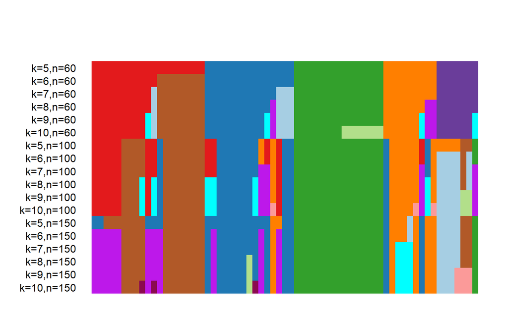

```r
clusterLabels(ce) = sub("FilterDims", "", clusterLabels(ce))
plotClusters(ce, whichClusters = "workflow", axisLine = -1)
```

```r
par(mar = .oldMar)
```

# 5.5 Ejemplos de agrupamiento: citometría de flujo y citometría de masas

## 5.5.1 Citometría de flujo y citometría de masas

```r
p_load("flowCore","flowViz")
fcsB = read.FCS("../data/Bendall_2011.fcs", truncate_max_range = FALSE)
slotNames(fcsB)
```

```
## [1] "exprs"       "parameters"  "description"
```

## 5.5.2 Preprocesamiento de datos

```r
markersB = readr::read_csv("../data/Bendall_2011_markers.csv")
mt = match(markersB$isotope, colnames(fcsB))
stopifnot(!any(is.na(mt)))
colnames(fcsB)[mt] = markersB$marker
```

Mediciones de celda que muestran un agrupamiento claro en dos dimensiones.

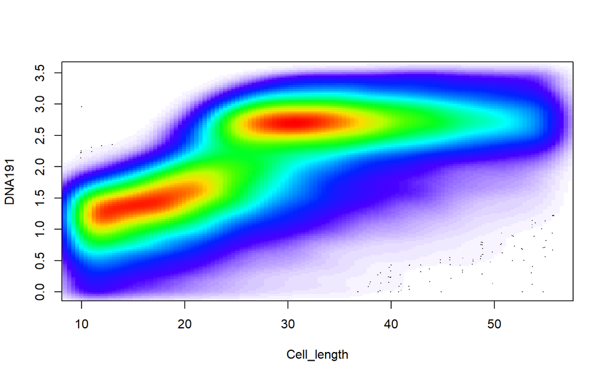

```r
flowPlot(fcsB, plotParameters = colnames(fcsB)[2:3], logy = TRUE)
```

Intente ejecutar el siguiente código para ver los dos regímenes principales de la transformación: valores pequeños y valores grandes.

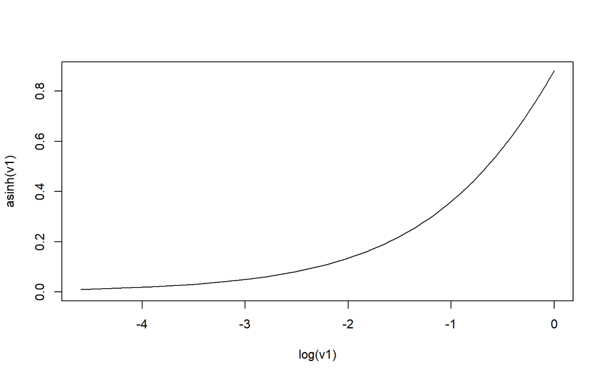

```r
v1 = seq(0, 1, length.out = 100)
plot(log(v1), asinh(v1), type = 'l')
```

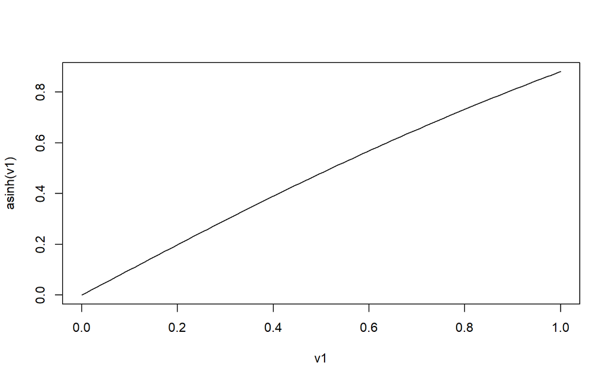

```r
plot(v1, asinh(v1), type = 'l')
```

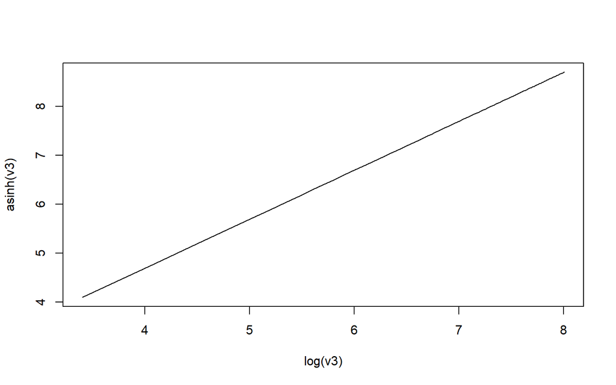

```r
v3 = seq(30, 3000, length = 100)
plot(log(v3), asinh(v3), type= 'l')
```

Este es otro ejemplo de una transformación estabilizadora de varianza.

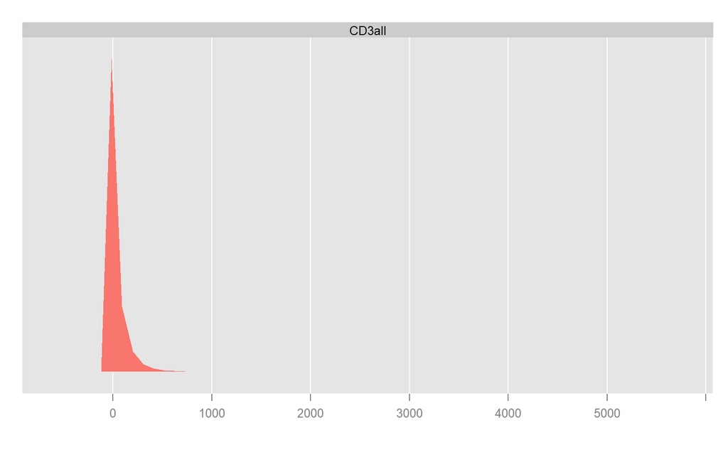

```r
asinhtrsf = arcsinhTransform(a = 0.1, b = 1)
fcsBT = transform(fcsB,
  transformList(colnames(fcsB)[-c(1, 2, 41)], asinhtrsf))
densityplot( ~`CD3all`, fcsB)
```

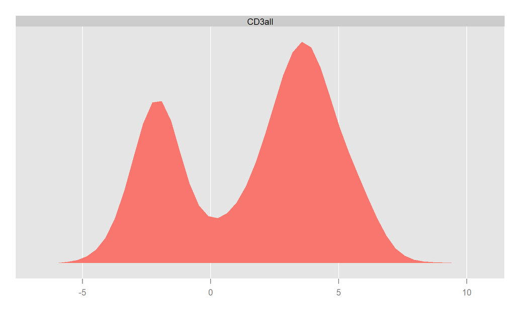

```r
densityplot( ~`CD3all`, fcsBT)
```

### Pregunta

¿Cuántas dimensiones usa el siguiente código para dividir los datos en 2 grupos usando k -medio ?

```r
kf = kmeansFilter("CD3all" = c("Pop1","Pop2"), filterId="myKmFilter")
fres = flowCore::filter(fcsBT, kf)
summary(fres)
```

```
## Pop1: 33434 of 91392 events (36.58%)
## Pop2: 57958 of 91392 events (63.42%)
```

```r
fcsBT1 = flowCore::split(fcsBT, fres, population = "Pop1")
fcsBT2 = flowCore::split(fcsBT, fres, population = "Pop2")
```

Después de la transformación, estas células se agruparon usando kmeans.

```r
p_load("flowPeaks")
fp = flowPeaks(Biobase::exprs(fcsBT)[, c("CD3all", "CD56")])
```

```
##         step 0, set the intial seeds, tot.wss=14636.9
##         step 1, do the rough EM, tot.wss=10278.9 at 0.468 sec
##         step 2, do the fine transfer of Hartigan-Wong Algorithm
##                  tot.wss=10221.1 at 1.115 sec
```

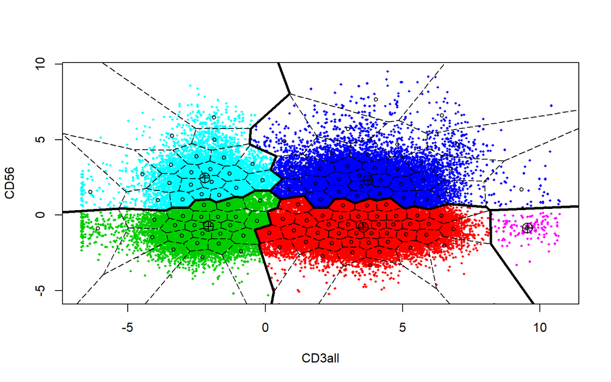

```r
plot(fp)
```

Al graficar puntos que pueblan densamente un área, aquí se usa contornos y sombreado. Esto se hace de la siguiente manera:

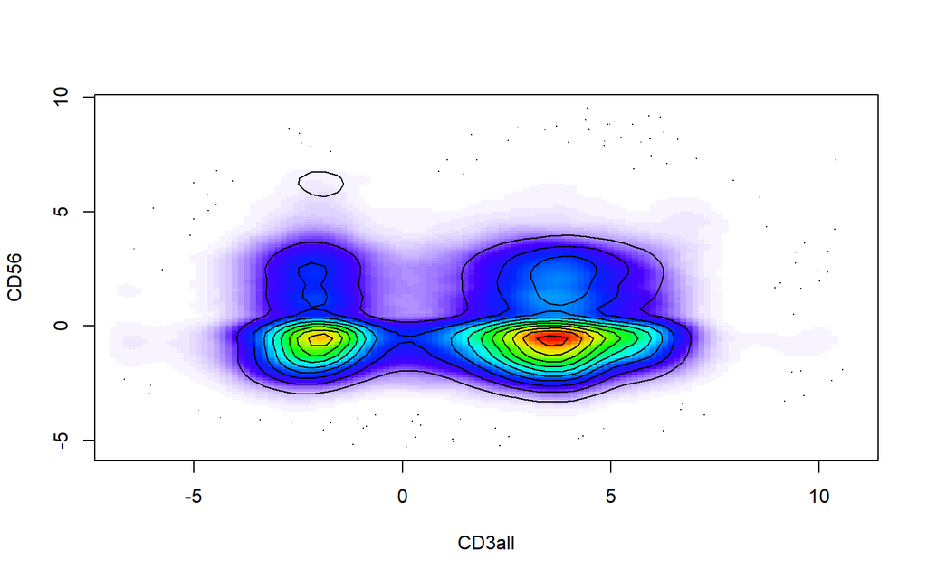

```r
flowPlot(fcsBT, plotParameters = c("CD3all", "CD56"), logy = FALSE)
contour(fcsBT[, c(40, 19)], add = TRUE)
```

```r
p_load("SamSPECTRAL")
mc2 = fcsBT@exprs[,c(40,33)]
head(mc2)
```

```
##         CD3all      CD56
## [1,]  4.002830  2.144493
## [2,] -2.318107  1.272534
## [3,]  3.688635 -1.207639
## [4,]  1.440554 -1.530669
## [5,]  3.266283 -1.139235
## [6,]  3.023840  1.055028
```

Intente comparar la salida usando este enfoque con lo que hicimos anteriormente usando lo siguiente:

```r
p_load("ggcyto","labeling")
ggcd4cd8=ggcyto(fcsB,aes(x=CD4,y=CD8))
ggcd4=ggcyto(fcsB,aes(x=CD4))
ggcd8=ggcyto(fcsB,aes(x=CD8))
p1=ggcd4+geom_histogram(bins=60)
p1b=ggcd8+geom_histogram(bins=60)
asinhT = arcsinhTransform(a=0,b=1)
transl = transformList(colnames(fcsB)[-c(1,2,41)], asinhT)
fcsBT = transform(fcsB, transl)
p1t=ggcyto(fcsBT,aes(x=CD4))+geom_histogram(bins=90)
p2t=ggcyto(fcsBT,aes(x=CD4,y=CD8))+geom_density2d(colour="black")
p3t=ggcyto(fcsBT,aes(x=CD45RA,y=CD20))+geom_density2d(colour="black")
```

## 5.5.3 Agrupamiento basado en la densidad

```r
p_load("dbscan")
mc5 = Biobase::exprs(fcsBT)[, c(15,16,19,40,33)]
res5 = dbscan::dbscan(mc5, eps = 0.65, minPts = 30)
mc5df = data.frame(mc5, cluster = as.factor(res5$cluster))
table(mc5df$cluster)
```

```
##
##     0     1     2     3     4     5     6     7     8
## 76053  4031  5450  5310   257   160    63    25    43
```

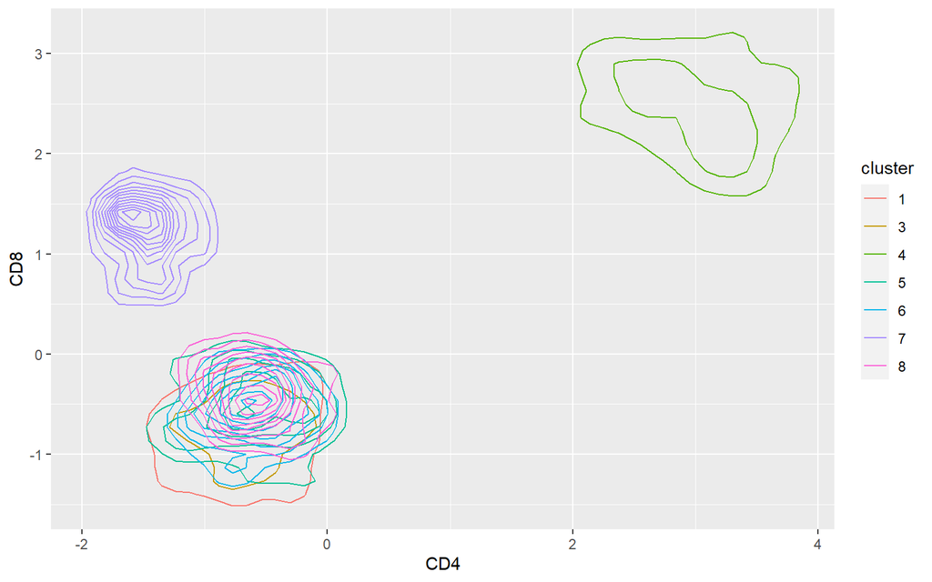

```r
ggplot(mc5df, aes(x=CD4,    y=CD8,  col=cluster))+geom_density2d()
```

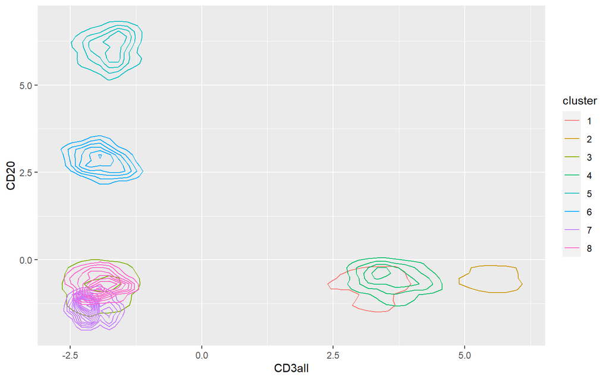

```r
ggplot(mc5df, aes(x=CD3all, y=CD20, col=cluster))+geom_density2d()
```

Estas dos gráficas muestran los resultados de agrupar con dbscanutilizando cinco marcadores. Aquí solo mostramos las proyecciones de los datos en los planos CD4-CD8 y C3all-CD20.

# 5.6 Agrupamiento jerárquico

## 5.6.1 ¿Cómo calcular (des) similitudes entre clústeres agregados?

```r
mc6 = Biobase::exprs(fcsBT)[, c(15, 16, 19, 33, 25, 40)]
res = dbscan::dbscan(mc6, eps = 0.65, minPts = 20)
mc6df = data.frame(mc6, cluster = as.factor(res$cluster))
table(mc6df$cluster)
```

```
##
##     0     1     2     3     4     5     6
## 91068    34    61    20    67   121    21
```

```r
mc7 = Biobase::exprs(fcsBT)[, c(11, 15, 16, 19, 25, 33, 40)]
res = dbscan::dbscan(mc7, eps = 0.95, minPts = 20)
mc7df = data.frame(mc7, cluster = as.factor(res$cluster))
table(mc7df$cluster)
```

```
##
##     0     1     2     3     4     5     6     7     8     9    10
## 90249    21   102   445   158   119    19   224    17    20    18
```

```r
## ####trees together par(mfrow)) not working for pheatmap
## library("pheatmap")
## load("../data/d14.RData")
## pheatmap(d14,clustering_distance_rows=d14,treeheight_col =200,
## cellwidth=20,cellheight=10,lwd=5,treeheight_row=0,clustering_method = "single",
## labels_col=1:11,main="single")
## pheatmap(d14,clustering_distance_rows=d14,treeheight_col =200,cellwidth=20,
## cellheight=10,lwd=5,treeheight_row=0,clustering_method = "average",
## labels_col=1:11,main="average")
## pheatmap(d14,clustering_distance_rows=d14,treeheight_col =200,cellwidth=20,
## cellheight=10,lwd=5,treeheight_row=0,clustering_method = "complete",labels_col=1:11,
## main="complete")
```

```r
## load("../data/Msig3transp.RData")
## celltypes=factor(substr(rownames(Msig3transp),7,9))
## status=factor(substr(rownames(Msig3transp),1,3))
## Msig2=as.matrix(Msig3transp)
## rownames(Msig2)=substr(rownames(Msig2),1,9)
## hm1=heatmap(as.matrix(dist(Msig2)))
## Morder=Msig2[hm1$rowInd,]
## save(Morder,file="../data/Morder.RData")
## write.table(Morder,"../data/Morder.txt")
```

```r
# p_load("gplots","pheatmap","RColorBrewer")
# load("../data/Morder.RData")
# celltypes=factor(substr(rownames(Morder),7,9))
# status=factor(substr(rownames(Morder),1,3))
# ##Just the Euclidean distance
# pheatmap(as.matrix(dist(Morder)),cluster_rows=FALSE,
#         cluster_cols=FALSE,cellwidth=10,cellheight=10)
# ###Manhattan
# pheatmap(as.matrix(dist(Morder,"manhattan")),cluster_rows=FALSE,
#         cluster_cols=FALSE,cellwidth=10,cellheight=10)
```

```r
# pheatmap(corT,clustering_distance_rows=distcor,
#        annotation_row=samplesdata[,c("celltypes","status")],
#        show_rownames = FALSE, show_colnames = FALSE)
# pheatmap(corT,clustering_distance_rows=distcor,treeheight_row =150,
#        annotation_row=samplesdata[,c("celltypes","status")],
#        show_rownames = FALSE, show_colnames = FALSE)
# pheatmap(corT,clustering_distance_rows=distcor,treeheight_row =150,
#        annotation_row=samplesdata[,c("celltypes","status")],
#        treeheight_col =150,
#        show_rownames = FALSE, show_colnames = FALSE)
# pheatmap(corT,clustering_distance_rows=distcor,treeheight_row =150,
#           annotation_col=samplesdata[,c("celltypes","status")],
#        annotation_row=samplesdata[,c("celltypes","status")],
#        treeheight_col =150,
#        show_rownames = FALSE, show_colnames = FALSE)
```

# 5.7 Validación y elección del número de clústeres

```r
p_load("dplyr")
simdat = lapply(c(0, 8), function(mx) {
  lapply(c(0,8), function(my) {
    tibble(x = rnorm(100, mean = mx, sd = 2),
           y = rnorm(100, mean = my, sd = 2),
           class = paste(mx, my, sep = ":"))
   }) %>% bind_rows
}) %>% bind_rows
head(simdat)
```

```
## # A tibble: 6 x 3
##        x      y class
##    <dbl>  <dbl> <chr>
## 1 -2.42  -4.59  0:0
## 2  1.89  -1.56  0:0
## 3  0.558  2.17  0:0
## 4  2.51  -0.873 0:0
## 5 -2.52  -0.766 0:0
## 6  3.62   0.953 0:0
```

```r
simdatxy = simdat[, c("x", "y")]
```

l simdatdatos coloreados por las etiquetas de clase. Aquí, conocemos las etiquetas desde que generamos los datos; por lo general, no las conocemos.

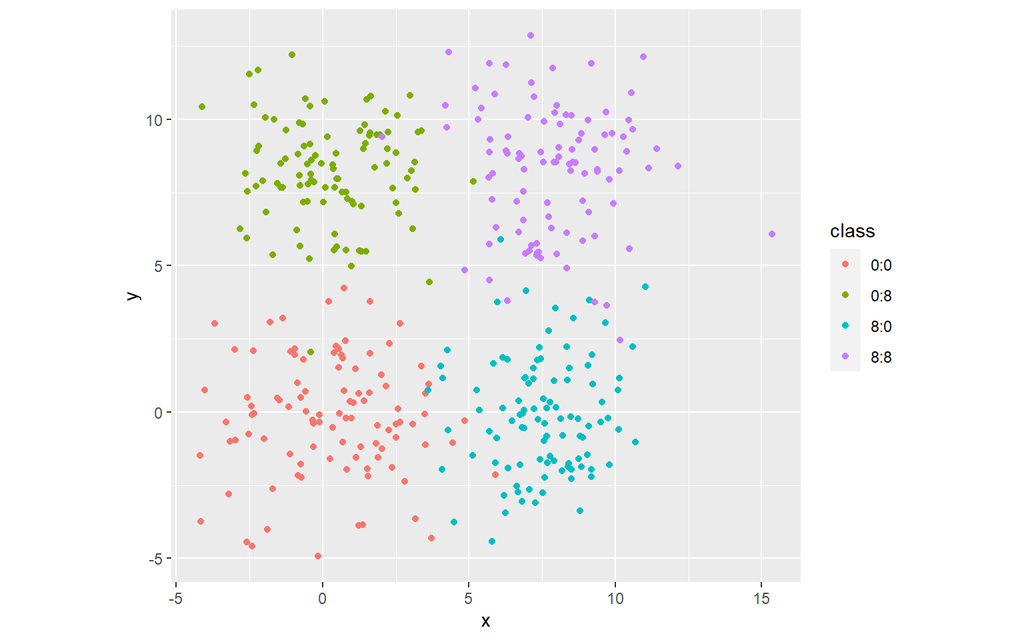

```r
ggplot(simdat, aes(x = x, y = y, col = class)) + geom_point() +
  coord_fixed()
```

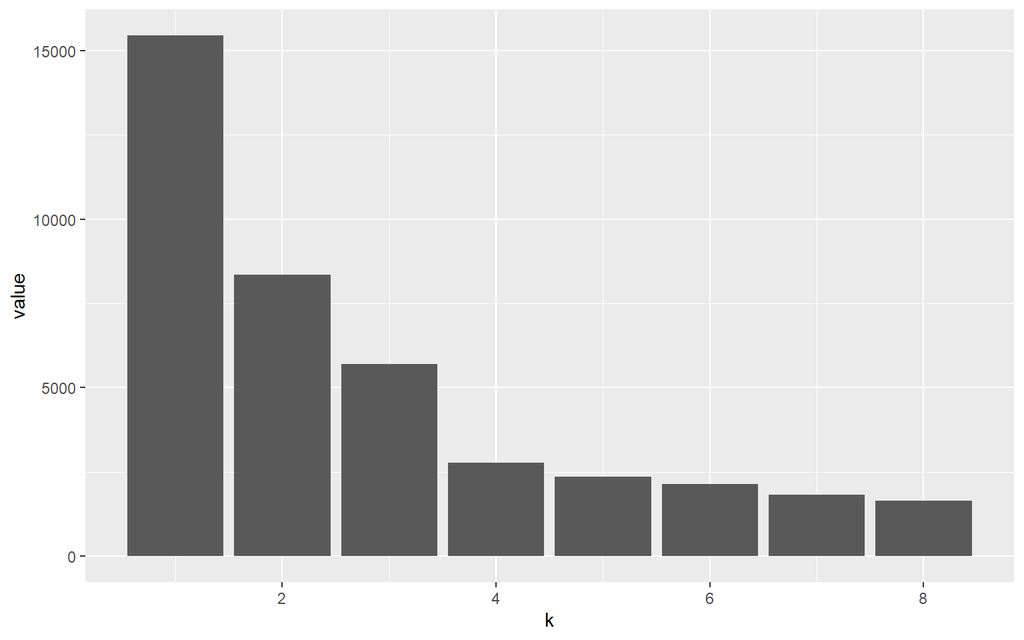

```r
wss = tibble(k = 1:8, value = NA_real_)
wss$value[1] = sum(scale(simdatxy, scale = FALSE)^2)
for (i in 2:nrow(wss)) {
  km  = kmeans(simdatxy, centers = wss$k[i])
  wss$value[i] = sum(km$withinss)
}
ggplot(wss, aes(x = k, y = value)) + geom_col()
```

El gráfico de barras del estadístico WSS en función de k muestra que el último salto sustancial es justo antes k = 4 . Esto indica que la mejor opción para estos datos es k = 4 .

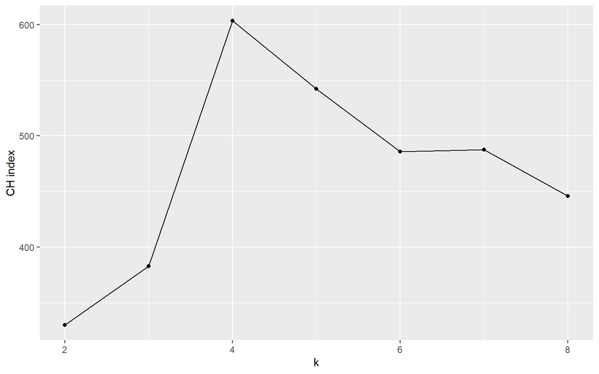

```r
p_load("fpc","cluster")
CH = tibble(
  k = 2:8,
  value = sapply(k, function(i) {
    p = pam(simdatxy, i)
    calinhara(simdatxy, p$cluster)
  })
)
ggplot(CH, aes(x = k, y = value)) + geom_line() + geom_point() +
  ylab("CH index")
```

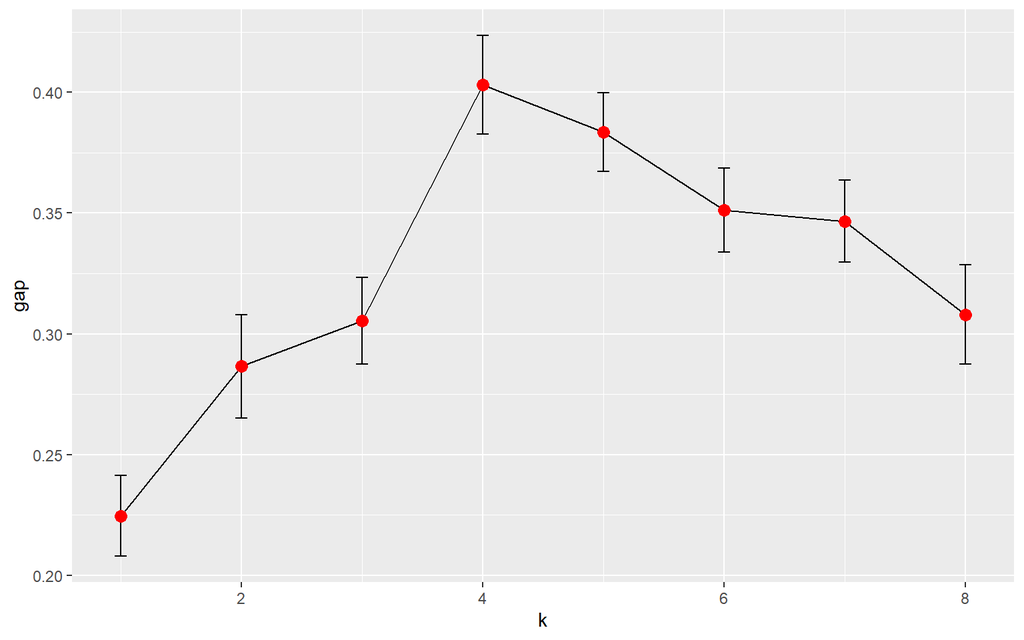

```r
p_load("cluster","ggplot2")
pamfun = function(x, k)
  list(cluster = pam(x, k, cluster.only = TRUE))
gss = clusGap(simdatxy, FUN = pamfun, K.max = 8, B = 50,
              verbose = FALSE)
plot_gap = function(x) {
  gstab = data.frame(x$Tab, k = seq_len(nrow(x$Tab)))
  ggplot(gstab, aes(k, gap)) + geom_line() +
    geom_errorbar(aes(ymax = gap + SE.sim,
                      ymin = gap - SE.sim), width=0.1) +
    geom_point(size = 3, col=  "red")
}
plot_gap(gss)
```

## 5.7.1 Uso de la estadística de la brecha

Haga una función que grafique la estadística de la brecha como en la Figura 5.27 . Mostrar la salida para el simdatconjunto de datos de ejemplo agrupado con el pamfunción.

```r
p_load("Hiiragi2013")
data("x")
```

Empezamos eligiendo los 50 genes (características) más variables.

```r
selFeats = order(rowVars(Biobase::exprs(x)), decreasing = TRUE)[1:50]
embmat = t(Biobase::exprs(x)[selFeats, ])
embgap = clusGap(embmat, FUN = pamfun, K.max = 24, verbose = FALSE)
k1 = maxSE(embgap$Tab[, "gap"], embgap$Tab[, "SE.sim"])
k2 = maxSE(embgap$Tab[, "gap"], embgap$Tab[, "SE.sim"],
           method = "Tibs2001SEmax")
c(k1, k2)
```

```
## [1] 9 7
```

```r
stopifnot("firstSEmax" == eval(formals(maxSE)$method)[1])
```

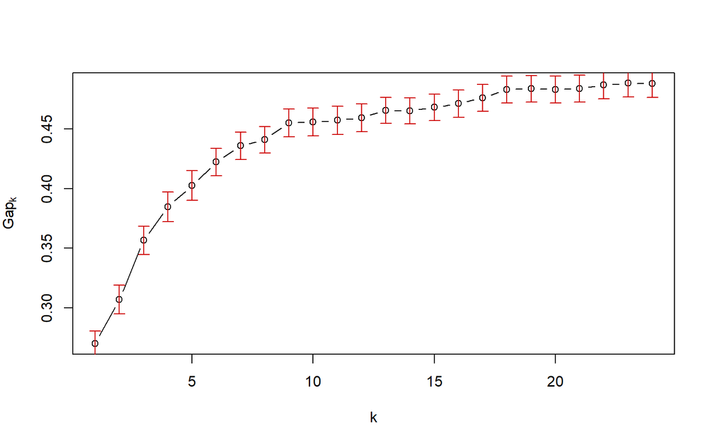

```r
plot(embgap, main = "")
```

```r
cl = pamfun(embmat, k = k1)$cluster
table(pData(x)[names(cl), "sampleGroup"], cl)
```

```
##                  cl
##                    1  2  3  4  5  6  7  8  9
##   E3.25           23 11  1  1  0  0  0  0  0
##   E3.25 (FGF4-KO)  0  0  1 16  0  0  0  0  0
##   E3.5 (EPI)       2  1  0  0  0  8  0  0  0
##   E3.5 (FGF4-KO)   0  0  8  0  0  0  0  0  0
##   E3.5 (PE)        0  0  0  0  9  2  0  0  0
##   E4.5 (EPI)       0  0  0  0  0  0  0  4  0
##   E4.5 (FGF4-KO)   0  0  0  0  0  0  0  0 10
##   E4.5 (PE)        0  0  0  0  0  0  4  0  0
```

La estadística de brecha para los Hiiragi2013 .

## 5.7.2 Validación de clúster mediante bootstrap

```r
clusterResampling = function(x, ngenes = 50, k = 2, B = 250,
                             prob = 0.67) {
  mat = Biobase::exprs(x)
  ce = cl_ensemble(list = lapply(seq_len(B), function(b) {
    selSamps = sample(ncol(mat), size = round(prob * ncol(mat)),
                      replace = FALSE)
    submat = mat[, selSamps, drop = FALSE]
    sel = order(rowVars(submat), decreasing = TRUE)[seq_len(ngenes)]
    submat = submat[sel,, drop = FALSE]
    pamres = pam(t(submat), k = k)
    pred = cl_predict(pamres, t(mat[sel, ]), "memberships")
    as.cl_partition(pred)
  }))
  cons = cl_consensus(ce)
  ag = sapply(ce, cl_agreement, y = cons)
  list(agreements = ag, consensus = cons)
}
```

```r
p_load(sampling, clue)
iswt = (x$genotype == "WT")
cr1 = clusterResampling(x[, x$Embryonic.day == "E3.25" & iswt])
cr2 = clusterResampling(x[, x$Embryonic.day == "E3.5"  & iswt])
```

Confirman la hipótesis de que los datos E.35 se dividen en dos grupos.

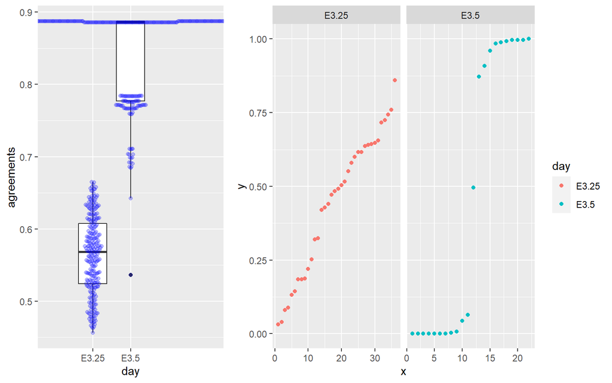

```r
ag1 = tibble(agreements = cr1$agreements, day = "E3.25")
ag2 = tibble(agreements = cr2$agreements, day = "E3.5")
p1 <- ggplot(bind_rows(ag1, ag2), aes(x = day, y = agreements)) +
  geom_boxplot() +
  ggbeeswarm::geom_beeswarm(cex = 1.5, col = "#0000ff40")
mem1 = tibble(y = sort(cl_membership(cr1$consensus)[, 1]),
              x = seq(along = y), day = "E3.25")
mem2 = tibble(y = sort(cl_membership(cr2$consensus)[, 1]),
              x = seq(along = y), day = "E3.5")
p2 <- ggplot(bind_rows(mem1, mem2), aes(x = x, y = y, col = day)) +
  geom_point() + facet_grid(~ day, scales = "free_x")
gridExtra::grid.arrange(p1, p2, widths = c(2.4,4.0))
```

# 5.8 El agrupamiento como medio para eliminar el ruido

## 5.8.1 Observaciones ruidosas con diferentes frecuencias de línea de base

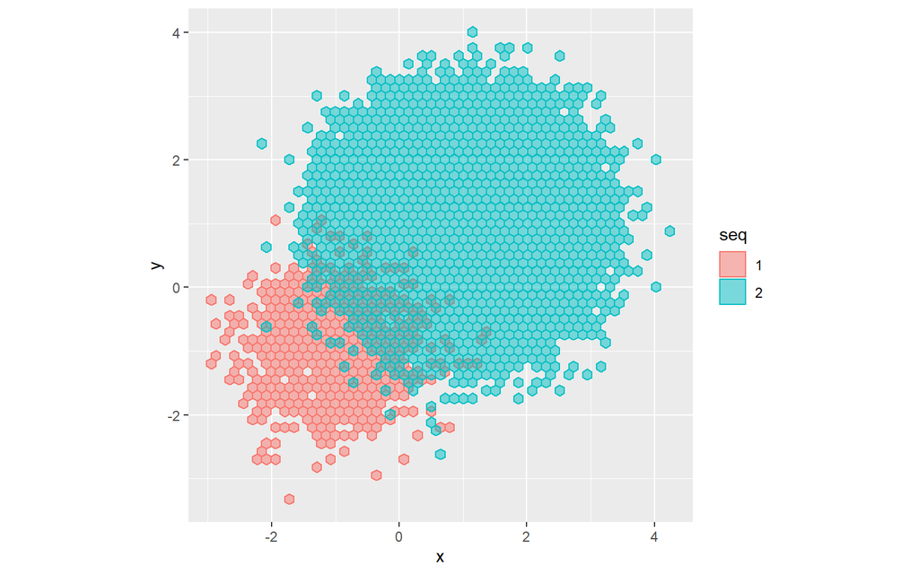

```r
library("mixtools","ggplot2")
seq1 = rmvnorm(n = 1e3, mu = -c(1, 1), sigma = 0.5 * diag(c(1, 1)))
seq2 = rmvnorm(n = 1e5, mu =  c(1, 1), sigma = 0.5 * diag(c(1, 1)))
twogr = data.frame(
  rbind(seq1, seq2),
  seq = factor(c(rep(1, nrow(seq1)),
                 rep(2, nrow(seq2))))
)
colnames(twogr)[1:2] = c("x", "y")
ggplot(twogr, aes(x = x, y = y, colour = seq,fill = seq)) +
  geom_hex(alpha = 0.5, bins = 50) + coord_fixed()
```

Simular n=2000variables binarias de longitud len=200que indican la calidad de nsecuenciación de lecturas de longitud len. Para simplificar, supongamos que los errores de secuenciación ocurren de manera independiente y uniforme con probabilidad perr=0.001. Es decir, solo nos importa si una base se llamó correctamente ( TRUE) O no ( FALSE).

```r
n    = 2000
len  = 200
perr = 0.001
seqs = matrix(runif(n * len) >= perr, nrow = n, ncol = len)
```

```r
dists = as.matrix(dist(seqs, method = "manhattan"))
```

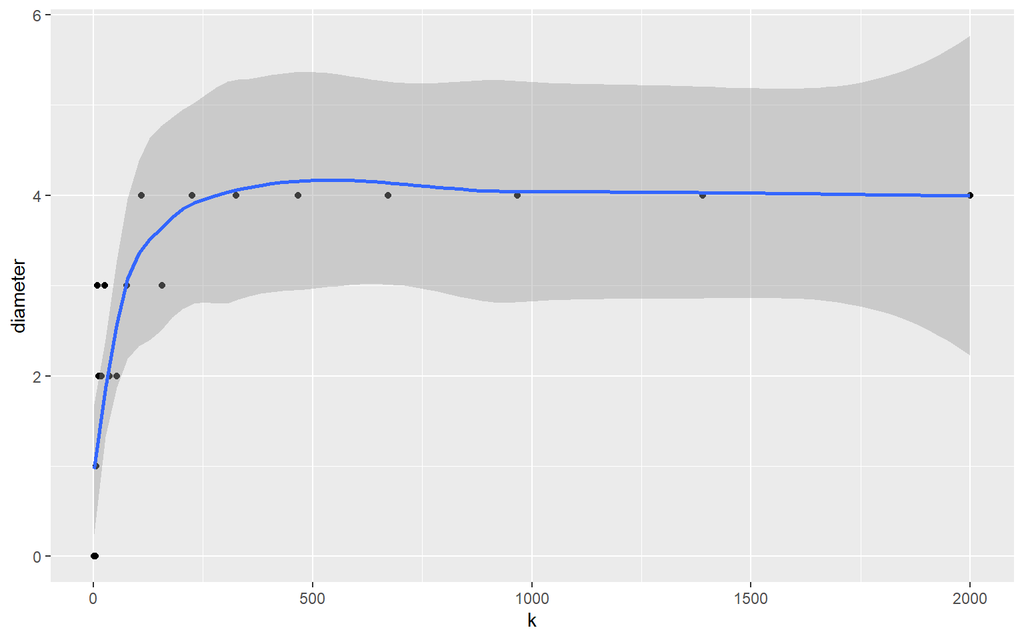

```r
p_load("tibble")
dfseqs = tibble(
  k = 10 ^ seq(log10(2), log10(n), length.out = 20),
  diameter = vapply(k, function(i) {
    s = sample(n, i)
    max(dists[s, s])
    }, numeric(1)))
ggplot(dfseqs, aes(x = k, y = diameter)) + geom_point()+geom_smooth()
```

## 5.8.3 Inferir variantes de secuencia

Las secuencias desreplicadas se leen y luego se ejecuta la eliminación de ruido divisiva y la estimación con el dadafuncionan como en el siguiente código.

```r
simseq10K = replicate(1e5, sum(rpois(200, 0.0005)))
mean(simseq10K)
```

```
## [1] 0.10143
```

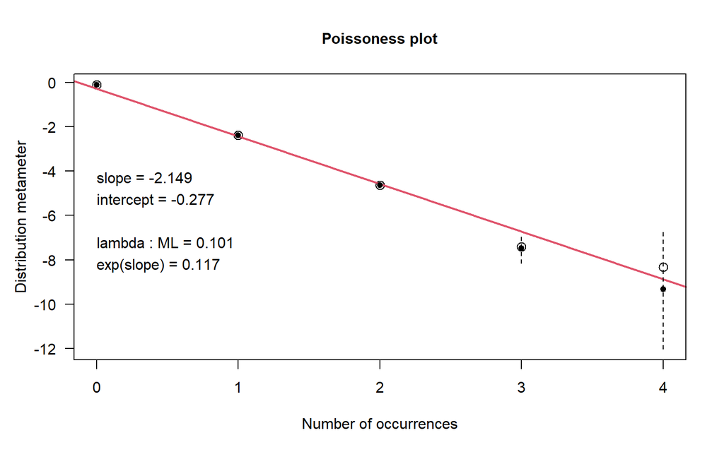

```r
vcd::distplot(simseq10K, "poisson")
```

```r
derepFs = readRDS(file="../data/derepFs.rds")
derepRs = readRDS(file="../data/derepRs.rds")
p_load("dada2")
ddF = dada(derepFs, err = NULL, selfConsist = TRUE)
```

```
## Initializing error rates to maximum possible estimate.
## selfConsist step 1 ....................
##    selfConsist step 2
##    selfConsist step 3
##    selfConsist step 4
##    selfConsist step 5
##    selfConsist step 6
## Convergence after  6  rounds.
```

```r
ddR = dada(derepRs, err = NULL, selfConsist = TRUE)
```

```
## Initializing error rates to maximum possible estimate.
## selfConsist step 1 ....................
##    selfConsist step 2
##    selfConsist step 3
##    selfConsist step 4
##    selfConsist step 5
##    selfConsist step 6
##    selfConsist step 7
## Convergence after  7  rounds.
```

Para verificar que las tasas de transición de error se hayan estimado razonablemente bien, inspeccionamos el ajuste entre las tasas de error observadas (puntos negros) y las tasas de error ajustadas (líneas negras)

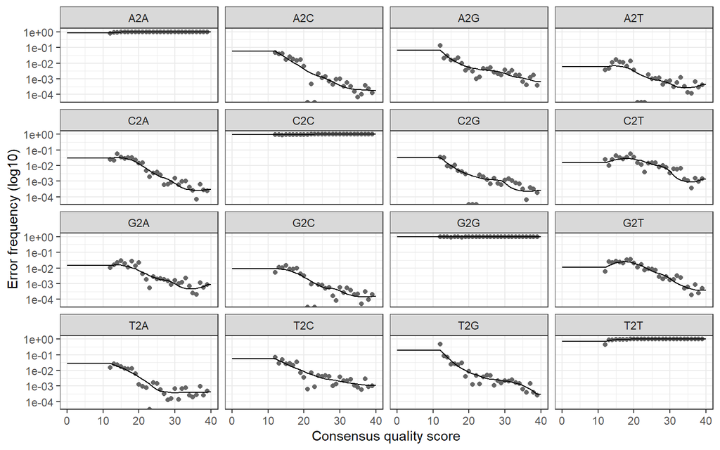

```r
plotErrors(ddF)
```

Una vez que se han estimado los errores, el algoritmo se vuelve a ejecutar en los datos para encontrar las variantes de la secuencia:

```r
dadaFs = dada(derepFs, err=ddF[[1]]$err_out, pool = TRUE)
```

```
## 20 samples were pooled: 139327 reads in 22977 unique sequences.
```

```r
dadaRs = dada(derepRs, err=ddR[[1]]$err_out, pool = TRUE)
```

```
## 20 samples were pooled: 139327 reads in 19360 unique sequences.
```

La inferencia de secuencias elimina casi todas las sustituciones y errores de los datos. Fusionamos las secuencias directa e inversa inferidas, mientras eliminamos las secuencias emparejadas que no se superponen perfectamente como control final contra los errores residuales.

```r
mergers = mergePairs(dadaFs, derepFs, dadaRs, derepRs)
```

Producimos una tabla de contingencia.

```r
seqtab.all = makeSequenceTable(mergers[!grepl("Mock",names(mergers))])
```

```r
dadada = unique(vapply(dadaRs, class, character(1)))
stopifnot(is.list(dadaRs), identical("dada", dadada))
```

```r
length(dadaRs)
```

```
## [1] 20
```

```r
length(dadaFs)
```

```
## [1] 20
```

```r
class(dadaRs)
```

```
## [1] "list"
```

```r
names(dadaRs)
```

```
##  [1] "F3D0"   "F3D1"   "F3D141" "F3D142" "F3D143" "F3D144" "F3D145" "F3D146"
##  [9] "F3D147" "F3D148" "F3D149" "F3D150" "F3D2"   "F3D3"   "F3D5"   "F3D6"
## [17] "F3D7"   "F3D8"   "F3D9"   "Mock"
```

```r
mergers = mergePairs(dadaFs, derepFs, dadaRs, derepRs)
class(mergers)
```

```
## [1] "list"
```

```r
length(mergers)
```

```
## [1] 20
```

### Pregunta

Explora los componentes de los objetos. dadaRsy mergers.

as quimeras son secuencias que se crean artificialmente durante la amplificación por PCR mediante la fusión de dos (en casos raros, más) de las secuencias originales. Para completar nuestro flujo de trabajo de eliminación de ruido, los eliminamos con una llamada a la función removeBimeraDenovo, dejándonos con una tabla de contingencia limpia que usaremos más adelante.

```r
seqtab = removeBimeraDenovo(seqtab.all)
```

# Ejercicios

Calcular el índice de silueta para el simdatdatos que simulamos.

[figure not shown]

```r
p_load("cluster")
pam4 = pam(simdatxy, 4)
sil = silhouette(pam4, 4)
plot(sil, col=c("red","green","blue","purple"), main="Silhouette")
```

Hacer una representación de “caracteres” de la distancia entre las 20 ubicaciones en el dunedatos del vegano paquete symnum.

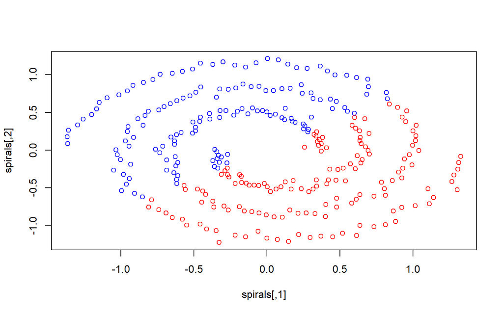

```r
p_load("kernlab")
data("spirals")
clusts = kmeans(spirals,2)$cluster
plot(spirals, col = c("blue", "red")[clusts])
```

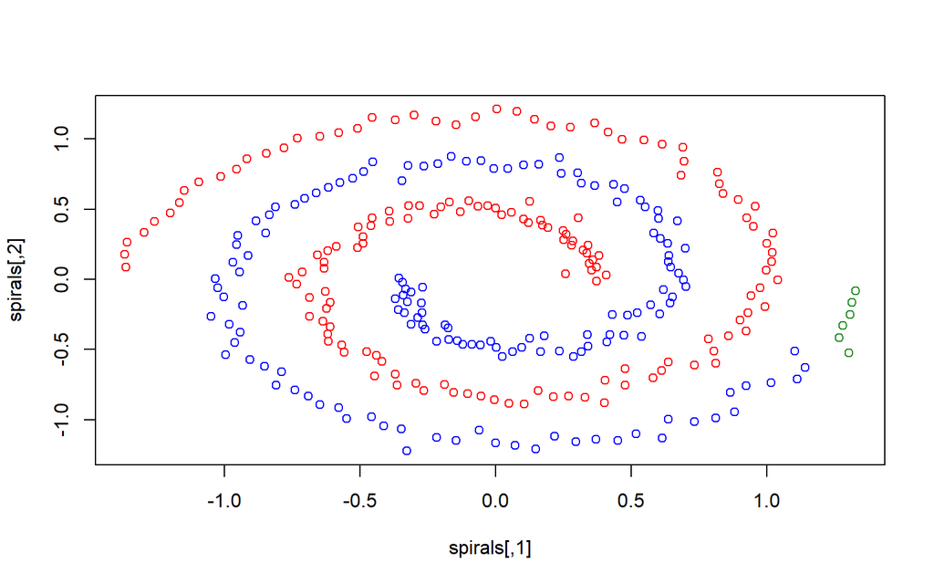

```r
data("spirals", package = "kernlab")
res.dbscan = dbscan::dbscan(spirals, eps = 0.16, minPts = 3)
plot(spirals,col=c("blue","red","forestgreen")[res.dbscan$cluster])
```

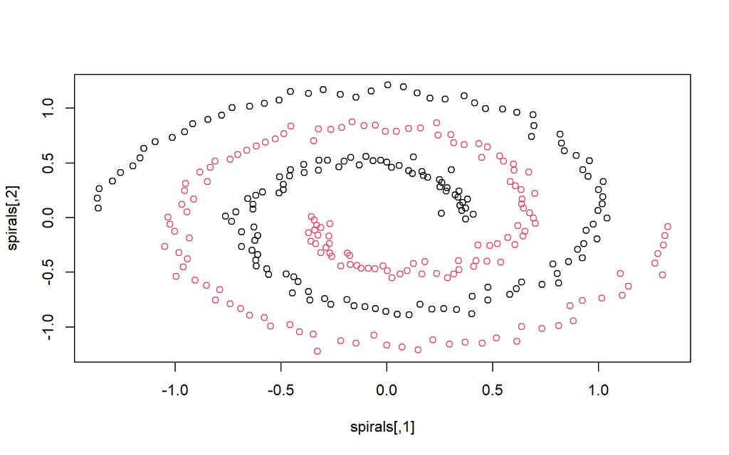

```r
sc = specc(spirals, centers=2)
plot(spirals, col=sc)
```

Bioinformática de amplicón: desde lecturas sin procesar hasta secuencias desreplicadas

```r
base_dir = "../data"
miseq_path = file.path(base_dir, "MiSeq_SOP")
filt_path = file.path(miseq_path, "filtered")
fnFs = sort(list.files(miseq_path, pattern="_R1_001.fastq"))
fnRs = sort(list.files(miseq_path, pattern="_R2_001.fastq"))
sampleNames = sapply(strsplit(fnFs, "_"), `[`, 1)
if (!file_test("-d", filt_path)) dir.create(filt_path)
filtFs = file.path(filt_path, paste0(sampleNames, "_F_filt.fastq.gz"))
filtRs = file.path(filt_path, paste0(sampleNames, "_R_filt.fastq.gz"))
fnFs = file.path(miseq_path, fnFs)
fnRs = file.path(miseq_path, fnRs)
print(length(fnFs))
```

```
## [1] 20
```

Tendremos que filtrar las lecturas de baja calidad y recortarlas a una longitud constante.

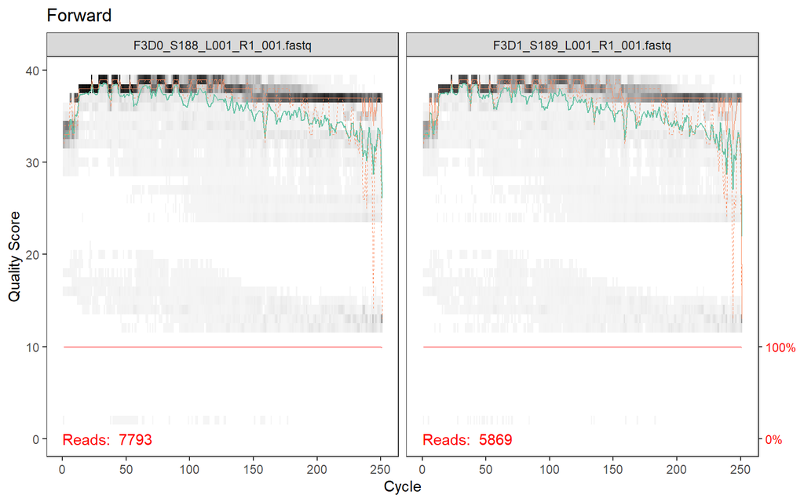

```r
plotQualityProfile(fnFs[1:2]) + ggtitle("Forward")
```